# Project 1: Wrangling, Exploration, Visualization

#### Wrangling

```r
tv_shows <- tv_shows %>% mutate(age = str_replace(age, "all",
    "0+")) %>% mutate(age = str_replace(age, "13+", "16+")) %>%
    mutate(age = replace_na(age, "0+")) %>% mutate(age = str_replace(age,
    "[+]", "")) %>% mutate(imdb = str_replace(imdb, "[?:\\/](?:\\d+)",
    "")) %>% mutate(rotten_tomatoes = str_replace(rotten_tomatoes,
    "[?:\\/](?:\\d+)", "")) %>% mutate(year = as.factor(year)) %>%
    mutate(age = as.numeric(age)) %>% mutate(imdb = as.numeric(imdb)) %>%
    mutate(rotten_tomatoes = as.numeric(rotten_tomatoes)) %>%
    na.omit %>% mutate(duration_hours = duration/60) %>% relocate(duration_hours,
    .after = duration)
glimpse(tv_shows)
```

```
## Rows: 1,159
## Columns: 12
## $ title           <chr> "The Family Man", "Lucifer", "The Handmaid's Tale", "…
## $ duration        <dbl> 42, 45, 42, 60, 57, 30, 41, 43, 44, 44, 49, 60, 60, 2…
## $ duration_hours  <dbl> 0.7000000, 0.7500000, 0.7000000, 1.0000000, 0.9500000…
## $ votes           <dbl> 57632, 252826, 187007, 18165, 29990, 261340, 207764, …
## $ year            <fct> 2019, 2016, 2017, 2016, 2018, 2005, 2013, 2018, 2010,…
## $ age             <dbl> 16, 16, 18, 18, 18, 16, 16, 18, 18, 18, 18, 18, 16, 1…
## $ imdb            <dbl> 8.8, 8.1, 8.4, 7.9, 8.2, 7.5, 8.0, 7.2, 8.2, 9.4, 8.8…
## $ rotten_tomatoes <dbl> 83, 90, 90, 77, 82, 87, 88, 76, 93, 100, 93, 93, 84, …
## $ netflix         <dbl> 0, 1, 0, 1, 1, 1, 1, 1, 1, 1, 1, 0, 0, 0, 0, 1, 1, 1,…
## $ hulu            <dbl> 0, 0, 1, 0, 0, 1, 0, 0, 0, 0, 0, 0, 1, 1, 1, 1, 0, 0,…
## $ prime_video     <dbl> 1, 0, 0, 0, 0, 0, 0, 0, 0, 0, 0, 1, 1, 1, 0, 0, 0, 0,…
## $ disney_plus     <dbl> 0, 0, 0, 0, 0, 0, 0, 0, 0, 0, 0, 0, 0, 0, 0, 0, 0, 0,…
```

```r
tv_shows %>% filter(netflix == 1) %>% nrow()
```

```
## [1] 481
```

```r
tv_shows %>% filter(hulu == 1) %>% nrow()
```

```
## [1] 508
```

```r
tv_shows %>% filter(prime_video == 1) %>% nrow()
```

```
## [1] 247
```

```r
tv_shows %>% filter(disney_plus == 1) %>% nrow()
```

```
## [1] 81
```

```r
average_score <- function(imdb, rotten_tomatoes) {
    ((imdb * 10) + rotten_tomatoes)/2
}
tv_shows %>% select(1:8) %>% select_if(is.numeric) %>% summarise_all(list(mean = mean,
    sd = sd, var = var, min = min, max = max))
```

```
## # A tibble: 1 x 30
##   duration_mean duration_hours_… votes_mean age_mean imdb_mean rotten_tomatoes…
##           <dbl>            <dbl>      <dbl>    <dbl>     <dbl>            <dbl>
## 1          45.8            0.763     35413.     12.4      7.36             66.3
## # … with 24 more variables: duration_sd <dbl>, duration_hours_sd <dbl>,
## #   votes_sd <dbl>, age_sd <dbl>, imdb_sd <dbl>, rotten_tomatoes_sd <dbl>,
## #   duration_var <dbl>, duration_hours_var <dbl>, votes_var <dbl>,
## #   age_var <dbl>, imdb_var <dbl>, rotten_tomatoes_var <dbl>,
## #   duration_min <dbl>, duration_hours_min <dbl>, votes_min <dbl>,
## #   age_min <dbl>, imdb_min <dbl>, rotten_tomatoes_min <dbl>,
## #   duration_max <dbl>, duration_hours_max <dbl>, votes_max <dbl>,
## #   age_max <dbl>, imdb_max <dbl>, rotten_tomatoes_max <dbl>
```

```r
longer_tv_shows <- tv_shows %>% pivot_longer(9:12, names_to = "service",
    values_to = "available") %>% filter(available == 1) %>% select(-available)
longer_tv_shows %>% group_by(service) %>% summarise(mean_duration = mean(duration),
    mean_duration_hours = mean(duration_hours), mean_imdb = mean(imdb),
    mean_rt = mean(rotten_tomatoes), mean_average_score = average_score(mean_imdb,
        mean_rt), count = n()) %>% arrange(desc(mean_average_score))
```

```
## # A tibble: 4 x 7
##   service mean_duration mean_duration_h… mean_imdb mean_rt mean_average_sc…
##   <chr>           <dbl>            <dbl>     <dbl>   <dbl>            <dbl>
## 1 prime_…          45.4            0.756      7.54    67.1             71.3
## 2 hulu             45.9            0.765      7.34    67.4             70.4
## 3 netflix          47.7            0.794      7.40    66.6             70.3
## 4 disney…          40.4            0.674      6.89    60.5             64.7
## # … with 1 more variable: count <int>
```

```r
tv_shows %>% group_by(year) %>% summarise(mean_duration = mean(duration),
    mean_duration_hours = mean(duration_hours), mean_imdb = mean(imdb),
    mean_rt = mean(rotten_tomatoes), mean_average_score = average_score(mean_imdb,
        mean_rt), count = n()) %>% arrange(desc(mean_average_score)) %>%
    filter(count > 5)
```

```
## # A tibble: 20 x 7
##    year  mean_duration mean_duration_h… mean_imdb mean_rt mean_average_sc… count
##    <fct>         <dbl>            <dbl>     <dbl>   <dbl>            <dbl> <int>
##  1 2015           46.7            0.778      7.55    70.3             72.9    93
##  2 2004           40.8            0.680      7.59    69.7             72.8    18
##  3 2005           37.2            0.621      7.42    70.0             72.1    33
##  4 2001           43              0.717      7.43    69.2             71.7    21
##  5 2011           41.2            0.686      7.41    69.3             71.7    53
##  6 2009           56.2            0.936      7.29    69.3             71.1    37
##  7 2013           45.8            0.763      7.44    67.0             70.7    74
##  8 2016           46.8            0.780      7.46    66.1             70.3   118
##  9 2008           40.8            0.679      7.38    66.4             70.1    26
## 10 2017           43.3            0.722      7.40    66.3             70.1   110
## 11 2014           45.5            0.758      7.35    66.4             70.0    75
## 12 2003           42.5            0.709      7.16    68.4             70.0    17
## 13 2012           49.1            0.818      7.34    64.4             68.9    59
## 14 2007           46.0            0.766      7.31    64.5             68.8    29
## 15 2018           46.4            0.773      7.29    64.4             68.6   133
## 16 2020           49.8            0.83       7.35    63.5             68.5    10
## 17 2002           32.6            0.544      7.25    64.2             68.4    14
## 18 2019           51.8            0.864      7.24    64.1             68.2   146
## 19 2010           44.5            0.742      7.29    63.5             68.2    49
## 20 2006           39.7            0.662      6.98    64.8             67.3    30
```

```r
longer_tv_shows %>% group_by(service, year) %>% summarise(mean_duration = mean(duration),
    mean_duration_hours = mean(duration_hours), mean_imdb = mean(imdb),
    mean_rt = mean(rotten_tomatoes), mean_average_score = average_score(mean_imdb,
        mean_rt), count = n()) %>% arrange(desc(mean_average_score)) %>%
    filter(count > 5)
```

```
## # A tibble: 52 x 8
## # Groups:   service [4]
##    service year  mean_duration mean_duration_h… mean_imdb mean_rt
##    <chr>   <fct>         <dbl>            <dbl>     <dbl>   <dbl>
##  1 prime_… 2013           48.7            0.812      7.98    74.5
##  2 hulu    2004           43.3            0.722      7.92    73.8
##  3 prime_… 2005           40.6            0.677      7.89    73.1
##  4 hulu    2001           45.8            0.762      7.68    74.8
##  5 hulu    2011           40              0.667      7.80    73.1
##  6 prime_… 2007           49.7            0.829      7.85    70.7
##  7 netflix 2011           44.5            0.742      7.58    73.3
##  8 prime_… 2015           52.5            0.875      7.90    69.8
##  9 netflix 2015           41.7            0.695      7.56    71.8
## 10 prime_… 2008           39.9            0.665      7.85    68.9
## # … with 42 more rows, and 2 more variables: mean_average_score <dbl>,
## #   count <int>
```

#### Visualizing

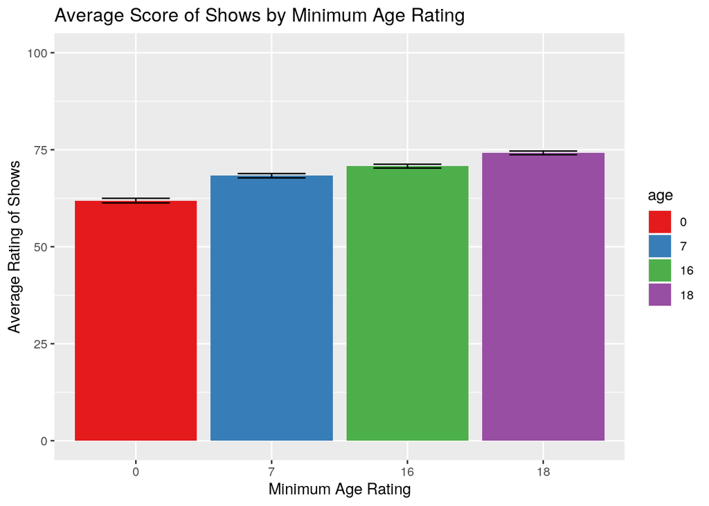

```r
tv_shows %>% mutate(age = as.factor(age)) %>% mutate(average_score = average_score(imdb,
    rotten_tomatoes)) %>% ggplot(aes(age, average_score)) + labs(title = "Average Score of Shows by Minimum Age Rating",
    x = "Minimum Age Rating", y = "Average Rating of Shows",
    breaks = 10) + geom_bar(stat = "summary", fun = "mean", aes(fill = age)) +
    scale_fill_brewer(palette = "Set1") + ylim(0, 100) + geom_errorbar(stat = "summary",
    width = 0.5)
```

This plot visualizes the relationship between the minimum age rating of a show with its average rating, and a visible trend is that the average rating tends to go up as the minimum age rating rises, which I am not surprised by as I have found that quality of tv shows increases significantly when made for an older audience.

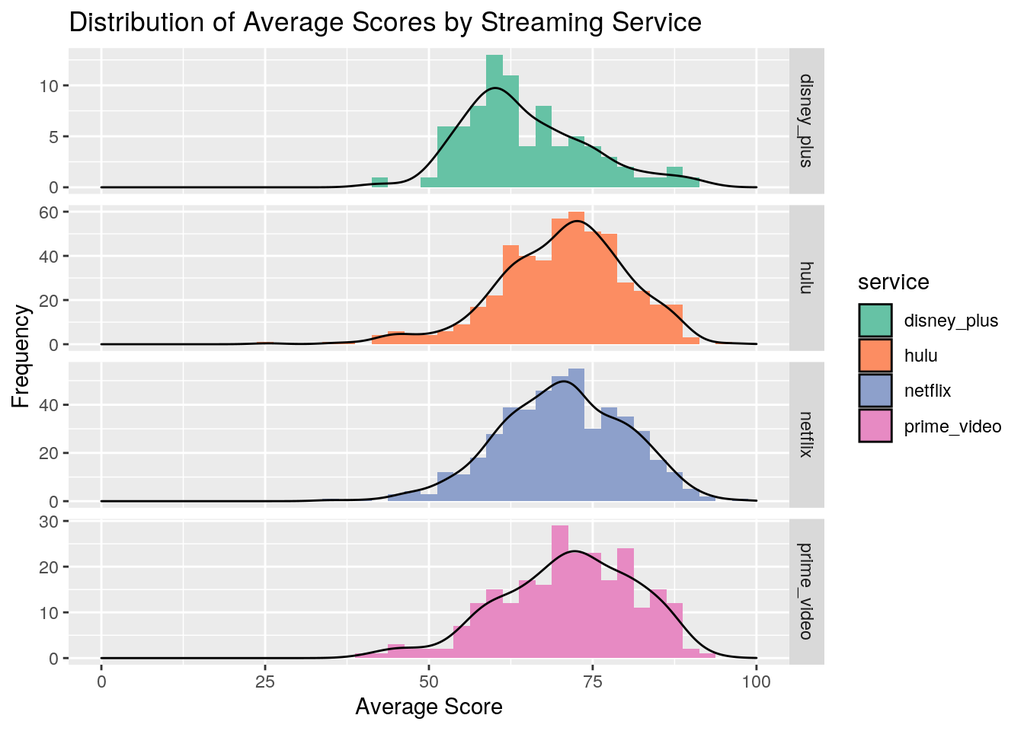

```r
longer_tv_shows %>% mutate(average_score = average_score(imdb,
    rotten_tomatoes)) %>% ggplot(aes(average_score)) + labs(title = "Distribution of Average Scores by Streaming Service",
    x = "Average Score", y = "Frequency", breaks = 10) + facet_grid(service ~
    ., scales = "free_y") + geom_histogram(binwidth = 2.5, aes(fill = service)) +
    geom_density(aes(y = 2.5 * ..count..)) + scale_fill_brewer(palette = "Set2") +
    xlim(0, 100)
```

This plot visualizes the distribution of average_score for each of the streaming services, and a visible trend is that hulu, netflix, and prime_video have relatively similar distributions around similar centers, while the disney_plus distribution has its center at a lower average_score and overall has a higher number of low score shows.

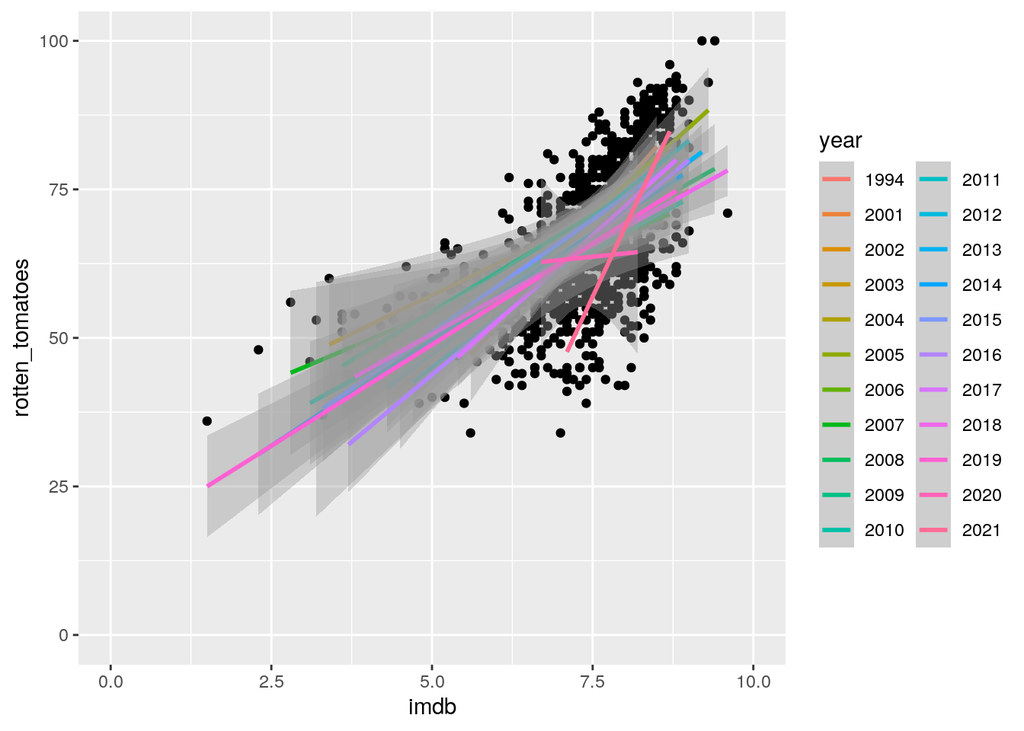

```r
tv_shows %>% ggplot(aes(imdb, rotten_tomatoes)) + geom_point() +
    geom_smooth(method = "lm", aes(color = year)) + xlim(0, 10) +
    ylim(0, 100) + scale_fill_brewer(palette = "Set3")
```

This plot shows the relationship between imdb score and rotten_tomatoes score, and we can visually see that there is a strong positive relationship, and from the way that trendlines are separated by year, we can see that this trend does not seem to change significantly year to year with a few exceptions(few movies in recent years due to covid), with a similar trendline with small variations throughout years.